# Tugas Kelompok 3

Praktikum Mata Kuliah Pemrograman Statistika (STA2561)

Authors

Eddy Junaidi (X1005261002)

Juryke Prasetyaning Tyas (M0501261024)

Olivia Firdaus (M0501261071)

# Soal 1. Pembersihan Data Mahasiswa

## 1. Membuat Data Frame

Data mahasiswa dibuat secara manual berdasarkan tabel yang diberikan pada soal.

```r
nilai_raw <- data.frame(
  Nama = c("Andi", "Budi", "Citra", "Dewi", "Andi"),
  Matematika = c(80, 90, NA, 75, 80),
  Statistika = c("85", "88", "78", "-", "85"),
  Umur = c(21, 20, 22, 21, 21),
  stringsAsFactors = FALSE)

nilai_raw
```

```
   Nama Matematika Statistika Umur
1  Andi         80         85   21
2  Budi         90         88   20
3 Citra         NA         78   22
4  Dewi         75          -   21
5  Andi         80         85   21
```

## 2. Mengidentifikasi Missing Value

Nilai `"-"` pada variabel `Statistika` diubah menjadi `NA` agar dapat dikenali sebagai missing value oleh R.

```r
nilai_raw$Statistika[nilai_raw$Statistika == "-"] <- NA

nilai_raw$Statistika <- as.numeric(nilai_raw$Statistika)

nilai_raw
```

```
   Nama Matematika Statistika Umur
1  Andi         80         85   21
2  Budi         90         88   20
3 Citra         NA         78   22
4  Dewi         75         NA   21
5  Andi         80         85   21
```

Jumlah missing value pada setiap variabel diperiksa menggunakan `is.na()`.

```r
colSums(is.na(nilai_raw))
```

```
      Nama Matematika Statistika       Umur
         0          1          1          0
```

## 3. Imputasi Missing Value

Missing value pada variabel `Statistika` diisi menggunakan nilai rata-rata dari nilai Statistika yang tersedia.

```r
mean_statistika <- mean(nilai_raw$Statistika, na.rm = TRUE)

mean_statistika
```

```
[1] 84
```

Nilai missing kemudian diganti dengan nilai rata-rata tersebut.

```r
nilai_raw$Statistika[is.na(nilai_raw$Statistika)] <- mean_statistika

nilai_raw
```

```
   Nama Matematika Statistika Umur
1  Andi         80         85   21
2  Budi         90         88   20
3 Citra         NA         78   22
4  Dewi         75         84   21
5  Andi         80         85   21
```

## 4. Membuat Variabel Status_Umur

Variabel `Status_Umur` dibuat menggunakan fungsi `ifelse()`.

Ketentuannya:

- Umur ≥ 21 tahun = Dewasa
- Umur < 21 tahun = Muda

```r
nilai_raw$Status_Umur <- ifelse(
  nilai_raw$Umur >= 21, "Dewasa", "Muda")

nilai_raw
```

```
   Nama Matematika Statistika Umur Status_Umur
1  Andi         80         85   21      Dewasa
2  Budi         90         88   20        Muda
3 Citra         NA         78   22      Dewasa
4  Dewi         75         84   21      Dewasa
5  Andi         80         85   21      Dewasa
```

## 5. Mengidentifikasi Data Duplikat

Pemeriksaan data duplikat dilakukan menggunakan fungsi `duplicated()`.

```r
duplicated(nilai_raw)
```

```
[1] FALSE FALSE FALSE FALSE  TRUE
```

Jumlah data yang terduplikasi dapat diketahui dengan:

```r
sum(duplicated(nilai_raw))
```

```
[1] 1
```

Data duplikat kemudian dihapus.

```r
nilai_bersih <- nilai_raw[!duplicated(nilai_raw), ]

nilai_bersih
```

```
   Nama Matematika Statistika Umur Status_Umur
1  Andi         80         85   21      Dewasa
2  Budi         90         88   20        Muda
3 Citra         NA         78   22      Dewasa
4  Dewi         75         84   21      Dewasa
```

## 6. Menyimpan Dataset Bersih

Dataset yang telah dibersihkan disimpan sebagai `nilai_bersih.csv`.

```r
write.csv(nilai_bersih, "nilai_bersih.csv", row.names = FALSE)
```

**Note**

Dataset yang telah disimpan dapat dilihat pada link berikut: [`nilai_bersih.csv`](https://eddyjuna.github.io/Praktikum-STA2561-X1005261002/nilai_bersih.csv)

# Soal 2. Subsetting dan Pengurutan Multikriteria

## 1. Membuat Data Frame Profil

Data profil dibuat secara manual berdasarkan tabel pada soal.

```r
profil <- data.frame(
  No = 1:10,
  gender = c("f", "f", "f", "m", "m",
             "f", "m", "m", "f", "m"),
  v1 = c(8, 15, 8, 14, 8, 10, 9, 9, 10, 12),
  v2 = c(9, 8, 13, 9, 2, 6, 9, 10, 13, 10),
  v3 = c(5, 9, 12, 8, 9, 10, 7, 8, 6, 9),
  v4 = c(9, 5, 6, NA, 16, 9, 13, 10, 7, 8),
  v5 = c(9, 10, 7, 11, 8, 10, 9, 5, 10, 17),
  v6 = c(9, 8, 9, 10, 10, 10, 12, 10, 12, 7),
  v7 = c(5, 10, 14, 6, 8, 9, 10, 6, 13, 9),
  v8 = c(9, 12, 12, 11, 9, 7, 9, 12, 9, 10),
  v9 = c(11, 9, 12, 11, 8, 7, 11, 6, 6, 7),
  v10 = c(8, 15, 9, 8, 9, 11, 7, 8, 9, 7)
  )

profil
```

```
   No gender v1 v2 v3 v4 v5 v6 v7 v8 v9 v10
1   1      f  8  9  5  9  9  9  5  9 11   8
2   2      f 15  8  9  5 10  8 10 12  9  15
3   3      f  8 13 12  6  7  9 14 12 12   9
4   4      m 14  9  8 NA 11 10  6 11 11   8
5   5      m  8  2  9 16  8 10  8  9  8   9
6   6      f 10  6 10  9 10 10  9  7  7  11
7   7      m  9  9  7 13  9 12 10  9 11   7
8   8      m  9 10  8 10  5 10  6 12  6   8
9   9      f 10 13  6  7 10 12 13  9  6   9
10 10      m 12 10  9  8 17  7  9 10  7   7
```

## 2. Filtering Berdasarkan Kriteria

Data difilter berdasarkan dua kondisi:

- `gender = "m"` dan `v1 > 9`
- atau `gender = "f"` dan `v3 <= 10`

```r
profil_filter <- profil[
  (profil$gender == "m" & profil$v1 > 9) |
  (profil$gender == "f" & profil$v3 <= 10), ]

profil_filter
```

```
   No gender v1 v2 v3 v4 v5 v6 v7 v8 v9 v10
1   1      f  8  9  5  9  9  9  5  9 11   8
2   2      f 15  8  9  5 10  8 10 12  9  15
4   4      m 14  9  8 NA 11 10  6 11 11   8
6   6      f 10  6 10  9 10 10  9  7  7  11
9   9      f 10 13  6  7 10 12 13  9  6   9
10 10      m 12 10  9  8 17  7  9 10  7   7
```

## 3. Pengurutan Multikriteria

Data hasil filtering diurutkan berdasarkan:

1. `gender`, *descending* dengan `"m"` terlebih dahulu.
2. `v5` secara *ascending* pada masing-masing kelompok gender.

```r
profil_filter <- profil_filter[
  order(profil_filter$gender != "m", profil_filter$v5), ]

profil_filter
```

```
   No gender v1 v2 v3 v4 v5 v6 v7 v8 v9 v10
4   4      m 14  9  8 NA 11 10  6 11 11   8
10 10      m 12 10  9  8 17  7  9 10  7   7
1   1      f  8  9  5  9  9  9  5  9 11   8
2   2      f 15  8  9  5 10  8 10 12  9  15
6   6      f 10  6 10  9 10 10  9  7  7  11
9   9      f 10 13  6  7 10 12 13  9  6   9
```

## 4. Menyimpan Hasil Filtering

Hasil filtering dan pengurutan disimpan sebagai `profil_filter.csv`.

```r
write.csv(profil_filter, "profil_filter.csv", row.names = FALSE)
```

**Note**

Dataset yang telah disimpan dapat dilihat pada link berikut: [`profil_filter.csv`](https://eddyjuna.github.io/Praktikum-STA2561-X1005261002/profil_filter.csv)

# Soal 3. Penggabungan dan Reshaping Data

## 1. Membuat Data Frame df_sales

Data penjualan toko dibuat dalam bentuk wide.

```r
df_sales <- data.frame(
  id_toko = c("T1", "T2", "T3"),
  Minggu1 = c(120, 150, 95),
  Minggu2 = c(135, 140, 110)
)

df_sales
```

```
  id_toko Minggu1 Minggu2
1      T1     120     135
2      T2     150     140
3      T3      95     110
```

## 2. Membuat Data Frame df_info

Data informasi kota masing-masing toko dibuat secara terpisah.

```r
df_info <- data.frame(
  id = c("T1", "T2", "T4"),
  Kota = c("Jakarta", "Bandung", "Surabaya")
)

df_info
```

```
  id     Kota
1 T1  Jakarta
2 T2  Bandung
3 T4 Surabaya
```

## 3. Full Outer Join

Penggabungan kedua data frame dilakukan menggunakan fungsi `merge()`.

Kolom kunci pada `df_sales` adalah `id_toko`, sedangkan kolom kunci pada `df_info` adalah `id`.

Parameter `all = TRUE` digunakan untuk melakukan full outer join sehingga seluruh data dari kedua tabel tetap dipertahankan.

```r
data_gabung <- merge(
  df_sales,
  df_info,
  by.x = "id_toko",
  by.y = "id",
  all = TRUE)

data_gabung
```

```
  id_toko Minggu1 Minggu2     Kota
1      T1     120     135  Jakarta
2      T2     150     140  Bandung
3      T3      95     110     <NA>
4      T4      NA      NA Surabaya
```

## 4. Reshaping Wide ke Long

Data penjualan diubah dari format wide menjadi format long.

Variabel `Minggu1` dan `Minggu2` digabungkan menjadi variabel `Waktu`, sedangkan nilai penjualan dimasukkan ke variabel `Penjualan`.

```r
penjualan_long <- reshape(
  data_gabung,
  varying = c("Minggu1","Minggu2"),
  v.names = "Penjualan",
  timevar = "Waktu",
  times = c("Minggu1","Minggu2"),
  idvar = "id_toko",
  direction = "long")

rownames(penjualan_long) <- NULL

penjualan_long
```

```
  id_toko     Kota   Waktu Penjualan
1      T1  Jakarta Minggu1       120
2      T2  Bandung Minggu1       150
3      T3     <NA> Minggu1        95
4      T4 Surabaya Minggu1        NA
5      T1  Jakarta Minggu2       135
6      T2  Bandung Minggu2       140
7      T3     <NA> Minggu2       110
8      T4 Surabaya Minggu2        NA
```

## 5. Menyimpan Data Long

Data hasil reshaping disimpan sebagai `penjualan_long.csv`.

```r
write.csv(penjualan_long, "penjualan_long.csv", row.names = FALSE)
```

**Note**

Dataset yang telah disimpan dapat dilihat pada link berikut: [`penjualan_long.csv`](https://eddyjuna.github.io/Praktikum-STA2561-X1005261002/penjualan_long.csv)

# Soal 4. Eksplorasi Visual

## 1. Mengenal Dataset CO2 dan Visualisasi Base R

### a. Mengenal Dataset CO2

Dataset `CO2` merupakan dataset bawaan R yang digunakan untuk mengeksplorasi hubungan antara konsentrasi CO2 dan penyerapan CO2 oleh tanaman.

```r
data(CO2)
```

Melihat struktur dataset:

```r
str(CO2)
```

```
Classes 'nfnGroupedData', 'nfGroupedData', 'groupedData' and 'data.frame':  84 obs. of  5 variables:
 $ Plant    : Ord.factor w/ 12 levels "Qn1"<"Qn2"<"Qn3"<..: 1 1 1 1 1 1 1 2 2 2 ...
 $ Type     : Factor w/ 2 levels "Quebec","Mississippi": 1 1 1 1 1 1 1 1 1 1 ...
 $ Treatment: Factor w/ 2 levels "nonchilled","chilled": 1 1 1 1 1 1 1 1 1 1 ...
 $ conc     : num  95 175 250 350 500 675 1000 95 175 250 ...
 $ uptake   : num  16 30.4 34.8 37.2 35.3 39.2 39.7 13.6 27.3 37.1 ...
 - attr(*, "formula")=Class 'formula'  language uptake ~ conc | Plant
  .. ..- attr(*, ".Environment")=<environment: R_EmptyEnv>
 - attr(*, "outer")=Class 'formula'  language ~Treatment * Type
  .. ..- attr(*, ".Environment")=<environment: R_EmptyEnv>
 - attr(*, "labels")=List of 2
  ..$ x: chr "Ambient carbon dioxide concentration"
  ..$ y: chr "CO2 uptake rate"
 - attr(*, "units")=List of 2
  ..$ x: chr "(uL/L)"
  ..$ y: chr "(umol/m^2 s)"
```

Melihat beberapa baris pertama:

```r
head(CO2)
```

```
  Plant   Type  Treatment conc uptake
1   Qn1 Quebec nonchilled   95   16.0
2   Qn1 Quebec nonchilled  175   30.4
3   Qn1 Quebec nonchilled  250   34.8
4   Qn1 Quebec nonchilled  350   37.2
5   Qn1 Quebec nonchilled  500   35.3
6   Qn1 Quebec nonchilled  675   39.2
```

Melihat ringkasan statistik:

```r
summary(CO2)
```

```
     Plant             Type         Treatment       conc          uptake
 Qn1    : 7   Quebec     :42   nonchilled:42   Min.   :  95   Min.   : 7.70
 Qn2    : 7   Mississippi:42   chilled   :42   1st Qu.: 175   1st Qu.:17.90
 Qn3    : 7                                    Median : 350   Median :28.30
 Qc1    : 7                                    Mean   : 435   Mean   :27.21
 Qc3    : 7                                    3rd Qu.: 675   3rd Qu.:37.12
 Qc2    : 7                                    Max.   :1000   Max.   :45.50
 (Other):42
```

Melihat nama variabel:

```r
names(CO2)
```

```
[1] "Plant"     "Type"      "Treatment" "conc"      "uptake"
```

Variabel yang digunakan dalam eksplorasi:

- `Plant` = identitas tanaman yang diamati, data berupa kategorik (factor).
- `Type` = tipe tanaman dari dua lokasi terdiri atas `Quebec` dan `Mississippi`, data berupa kategorik (factor).
- `Treatment` = perlakuan temperatur yang diberikan kepada tanaman terdiri atas `chilled` (perlakuan suhu dingin) dan `nonchilled` (perlakuan suhu normal), data berupa kategorik (factor).
- `conc` = konsentrasi CO2 yang diberikan kepada tanaman, data berupa numerik.
- `uptake` = penyerapan CO2 oleh tanaman, data berupa numerik.

### b. Visualisasi Base R

Hubungan antara konsentrasi CO2 (`conc`) dan penyerapan CO2 (`uptake`) dibuat menggunakan `plot()`.

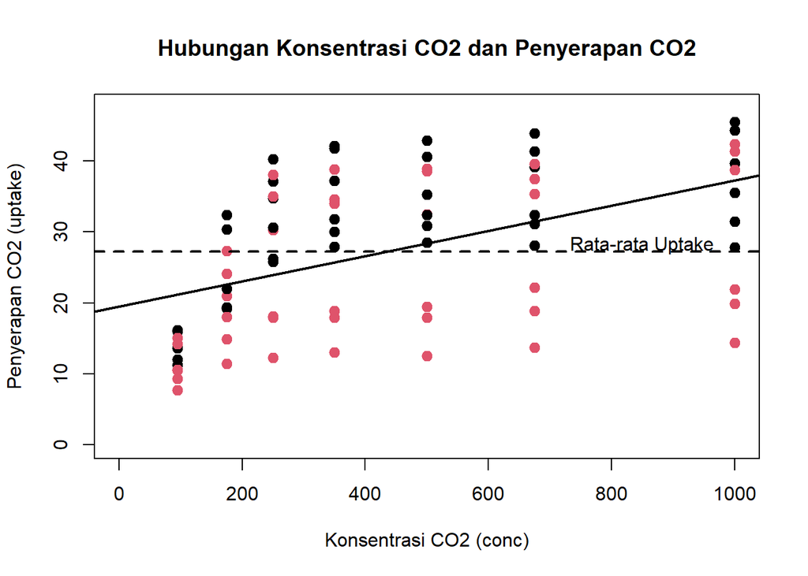

```r
plot(
  CO2$conc,CO2$uptake,
  pch = 19,
  cex = 1.2,
  col = as.numeric(CO2$Treatment),
  main = "Hubungan Konsentrasi CO2 dan Penyerapan CO2",
  xlab = "Konsentrasi CO2 (conc)",
  ylab = "Penyerapan CO2 (uptake)",
  xlim = c(0, 1000),
  ylim = c(0, max(CO2$uptake) + 2)
)

abline(
  h = mean(CO2$uptake),
  lty = 2,
  lwd = 2
)

text(
  x = 850,
  y = mean(CO2$uptake) + 1,
  labels = "Rata-rata Uptake"
)

abline(
  lm(uptake ~ conc, data = CO2),
  lwd = 2
)
```

## 2. Empat Visualisasi dalam Satu Tampilan

Empat grafik dibuat dalam satu tampilan menggunakan `par(mfrow = c(2,2))`.

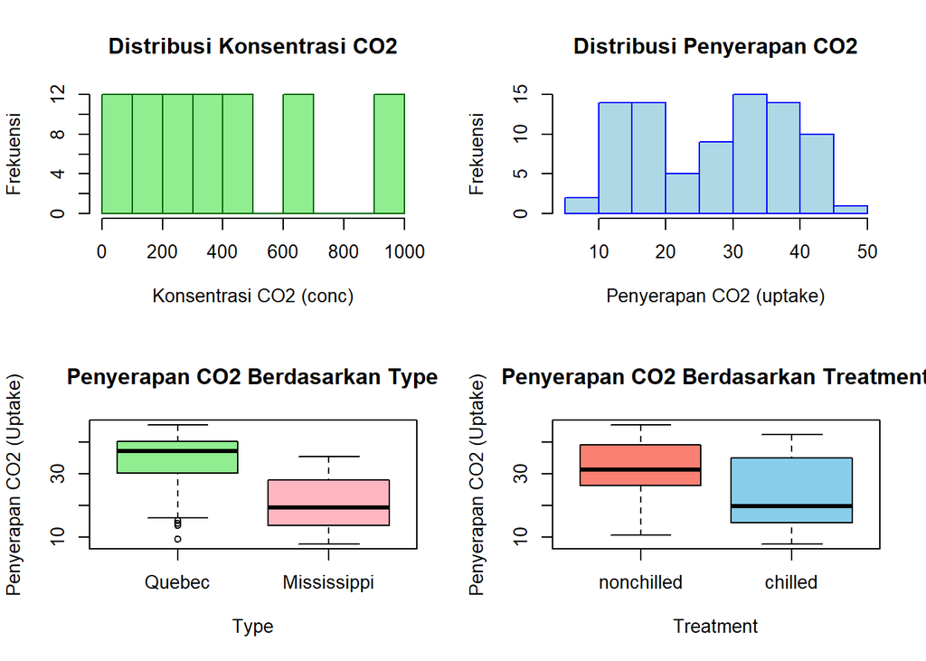

```r
par(mfrow = c(2, 2))

hist(
  CO2$conc,
  col = "lightgreen", border = "darkgreen",
  main = "Distribusi Konsentrasi CO2",
  xlab = "Konsentrasi CO2 (conc)",
  ylab = "Frekuensi"
)

hist(
  CO2$uptake,
  col = "lightblue", border = "blue",
  main = "Distribusi Penyerapan CO2",
  xlab = "Penyerapan CO2 (uptake)",
  ylab = "Frekuensi"
)

boxplot(
  uptake ~ Type, data = CO2,
  col = c("lightgreen","lightpink"),
  main = "Penyerapan CO2 Berdasarkan Type",
  xlab = "Type",
  ylab = "Penyerapan CO2 (Uptake)"
)

boxplot(
  uptake ~ Treatment, data = CO2,
  col = c("salmon","skyblue"),
  main = "Penyerapan CO2 Berdasarkan Treatment",
  xlab = "Treatment",
  ylab = "Penyerapan CO2 (Uptake)"
)
```

## 3. Visualisasi Menggunakan qplot() dan ggplot()

### a. Visualisasi Menggunakan qplot()

Package `ggplot2` digunakan untuk membuat visualisasi.

```r
library(ggplot2)
```

Visualisasi hubungan antara `conc` dan `uptake` berdasarkan `Treatment` dibuat menggunakan `qplot()`.

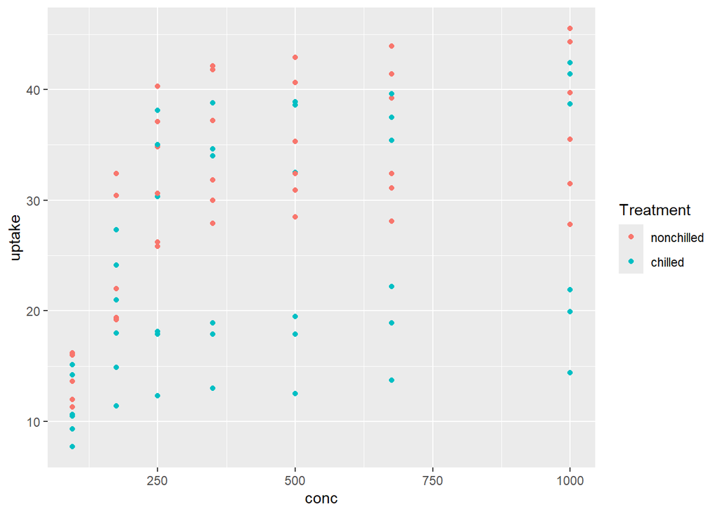

```r
qplot(
  x = conc,
  y = uptake,
  data = CO2,
  color = Treatment,
  geom = "point"
)
```

### b. Visualisasi Menggunakan ggplot2

Pada grafik berikut:

- `conc` digunakan sebagai sumbu X.
- `uptake` digunakan sebagai sumbu Y.
- `Treatment` digunakan untuk membedakan warna.
- `Type` digunakan untuk membedakan bentuk titik.

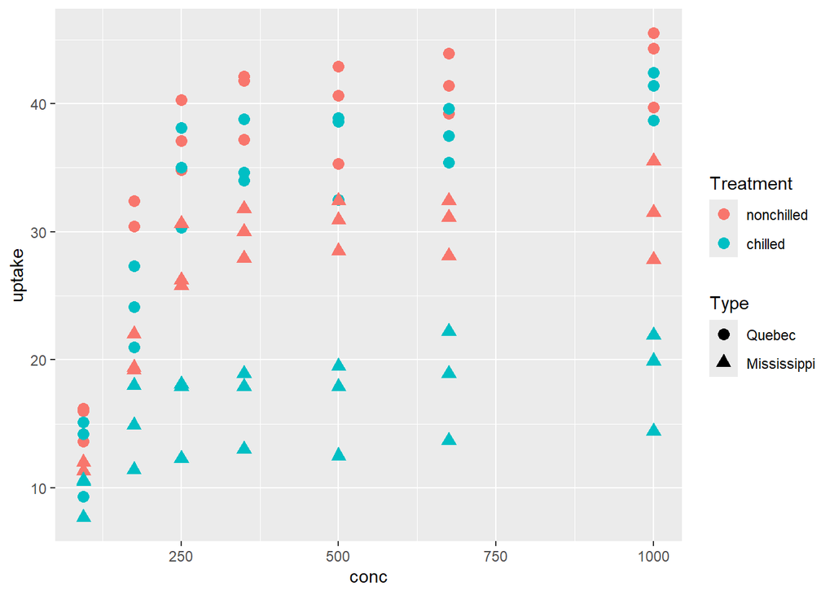

```r
grafik_co2 <- ggplot(
  CO2,
  aes(x = conc, y = uptake,
      color = Treatment,
      shape = Type)) +
  geom_point(size = 3)

grafik_co2
```

## 4. Pengembangan Visualisasi ggplot2

### a. Menambahkan stat_*

`stat_smooth()` digunakan untuk menambahkan garis kecenderungan hubungan antara konsentrasi CO2 dan uptake berdasarkan `Treatment`.

```
Warning: The following aesthetics were dropped during statistical transformation: shape.
ℹ This can happen when ggplot fails to infer the correct grouping structure in
  the data.
ℹ Did you forget to specify a `group` aesthetic or to convert a numerical
  variable into a factor?
```

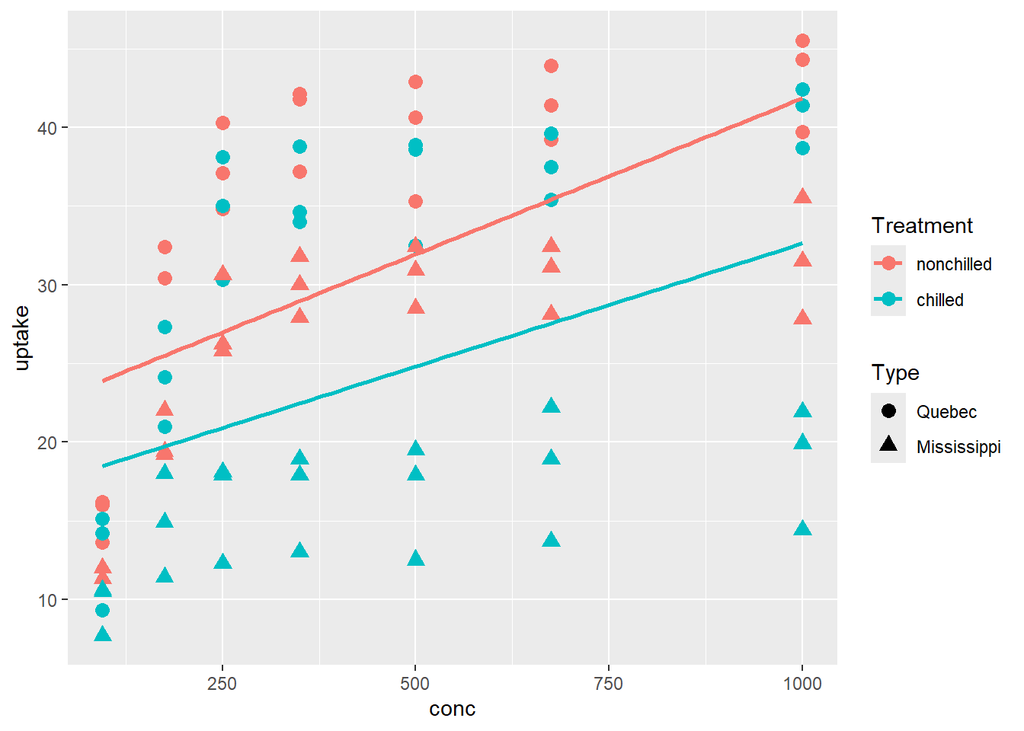

```r
grafik_co2_final <- ggplot(
  CO2,
  aes(x = conc, y = uptake,
      color = Treatment,
      shape = Type)) +
  geom_point(size = 3) +
  stat_smooth(
    aes(group = Treatment),
    method = "lm",
    se = FALSE
  )

grafik_co2_final
```

### b. Menambahkan scale_*

`scale_color_manual()` digunakan untuk mengatur warna berdasarkan kategori `Treatment`.

```
Warning: The following aesthetics were dropped during statistical transformation: shape.
ℹ This can happen when ggplot fails to infer the correct grouping structure in
  the data.
ℹ Did you forget to specify a `group` aesthetic or to convert a numerical
  variable into a factor?
```

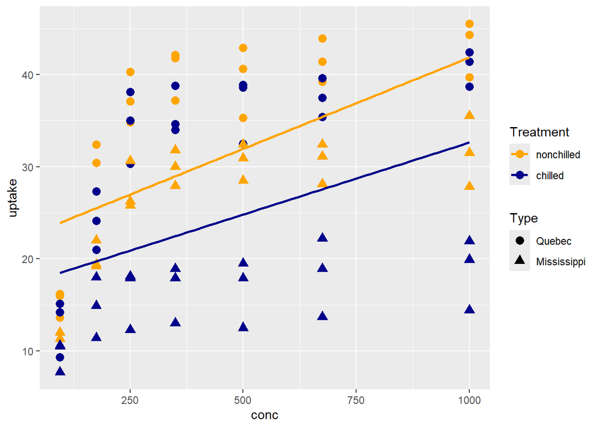

```r
grafik_co2_final <- grafik_co2_final +
  scale_color_manual(
    values = c("chilled" = "darkblue",
               "nonchilled" = "orange")
  )

grafik_co2_final
```

### c. Menambahkan coord_*

`coord_cartesian()` digunakan untuk mengatur rentang sumbu X dan Y.

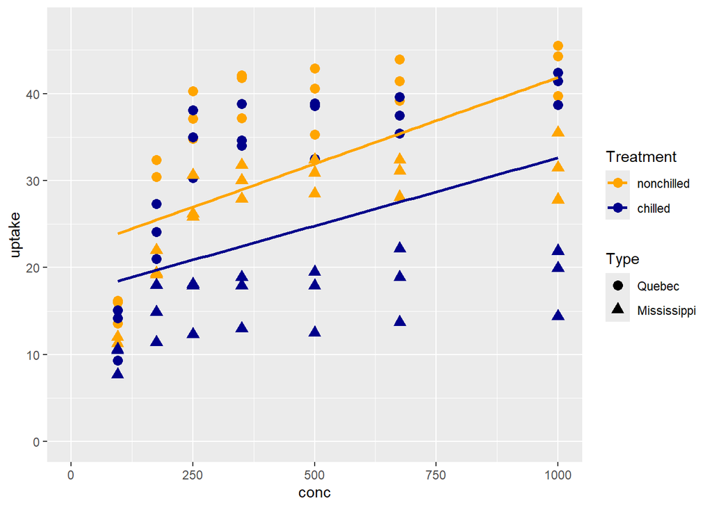

```r
grafik_co2_final <- grafik_co2_final +
  coord_cartesian(
    xlim = c(0, 1000),
    ylim = c(0,max(CO2$uptake) + 2)
  )

grafik_co2_final
```

### d. Menambahkan labs()

`labs()` digunakan untuk memberikan judul, subtitle, nama sumbu, dan keterangan legenda.

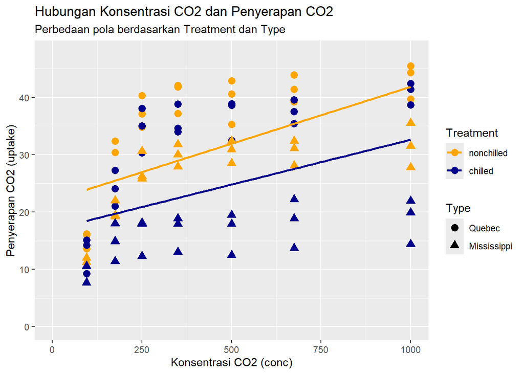

```r
grafik_co2_final <- grafik_co2_final +
  labs(
    title = "Hubungan Konsentrasi CO2 dan Penyerapan CO2",
    subtitle = "Perbedaan pola berdasarkan Treatment dan Type",
    x = "Konsentrasi CO2 (conc)",
    y = "Penyerapan CO2 (uptake)",
    color = "Treatment",
    shape = "Type"
  )

grafik_co2_final
```

### e. Menambahkan Theme

Tema grafik diatur menggunakan `theme_minimal()` yaitu tampilan sederhana.

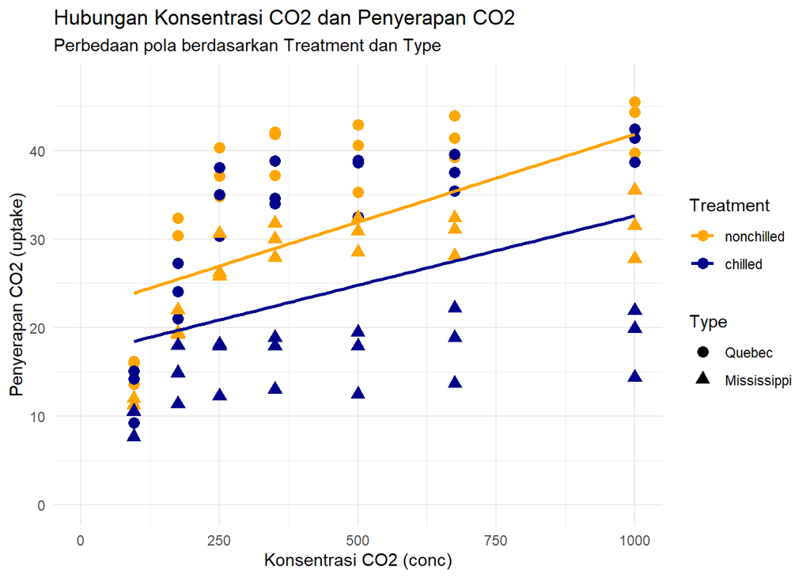

```r
grafik_co2_final <- grafik_co2_final +
  theme_minimal()

grafik_co2_final
```

## 5. Menyimpan Grafik

Grafik akhir disimpan dalam format PNG menggunakan `ggsave()` dengan nama `co2_uptake_visualisasi.png`.

```r
ggsave(
  filename = "co2_uptake_visualisasi.png",
  plot = grafik_co2_final,
  width = 10, height = 7, dpi = 300
)
```

**Note**

Grafik akhir yang telah disimpan dapat dilihat pada link berikut: [`co2_uptake_visualisasi.png`](https://eddyjuna.github.io/Praktikum-STA2561-X1005261002/co2_uptake_visualisasi.png)

## 6. Interpretasi

Berdasarkan visualisasi hubungan antara konsentrasi CO2 (`conc`) dan penyerapan CO2 (`uptake`), secara umum terlihat kecenderungan positif bahwa peningkatan konsentrasi CO2 diikuti oleh peningkatan penyerapan CO2 oleh tanaman. Namun, peningkatan tersebut tidak sepenuhnya linear karena pada konsentrasi yang lebih tinggi peningkatan `uptake` cenderung melambat.

Perbedaan warna pada grafik menunjukkan adanya perbedaan pola antara treatment **chilled** dan **nonchilled**. Hal tersebut menunjukkan bahwa treatment dapat berkaitan dengan perbedaan kemampuan tanaman dalam menyerap CO2.

Perbedaan bentuk titik juga menunjukkan adanya variasi berdasarkan `Type`. Dengan demikian, pola uptake tidak hanya dapat dilihat berdasarkan konsentrasi CO2, tetapi juga perlu mempertimbangkan tipe tanaman dan treatment yang diberikan.

Secara keseluruhan, visualisasi menunjukkan bahwa hubungan antara konsentrasi CO2 dan penyerapan CO2 memiliki pola yang berbeda berdasarkan karakteristik tanaman dan treatment.